# Cell type annotation

To perform DE analysis on a per cell type basis, we need to wrangle our data in a couple ways. We need to do the following steps:

- Split our data by cell type
- Transform the matrix so that the genes are the row names and the samples are the column names

We will split our data by cell type; however, not always do all samples contain cells of every cell type. To determine which samples are present for each cell type we can run the following:

```r
splitf <- sapply(stringr::str_split(rownames(pb),
                                    pattern = "_",
                                    n = 2),
                 `[`, 1)
```

Now we can turn the matrix into a list that is split into count matrices for each cluster, then transform each data frame so that rows are genes and columns are the samples.

```r
# Turn into a list and split the list into components for each cluster and transform, so rows are genes and columns are samples and make rownames as the sample IDs
pb <- split.data.frame(pb,
                       factor(splitf)) %>%
        lapply(function(u)
                set_colnames(t(u),
                             stringr::str_extract(rownames(u), "(?<=_)[:alnum:]+")))

class(pb)

# Explore the different components of list
str(pb)
```

[output not shown]

The counts per sample for each cluster can be checked:

```r
# Print out the table of cells in each cluster-sample group
options(width = 100)
table(sce$cluster_id, sce$sample_id)[1:6,1:6]
```

```
                  ctrl1000 ctrl1001 ctrl1002 ctrl1003 ctrl1004 ctrl1005
  B cells                2        3        1        2        5        2
  CD4+ T cells           6        2        5        5        7        5
  CD8+ T cells           3        1        1        5        3        2
  Dendritic cells        0        0        0        0        0        0
  Monocytes              1        0        1        0        0        3
  Neutrophils            0        0        0        0        0        0
```

Sample-level metadata

To perform the DE analysis, we need metadata for all samples, including cluster ID, sample ID and the condition(s) of interest (group_id), in addition to any other sample-level metadata (e.g. batch, sex, age, etc.). The ei data frame holds the sample ID and condition information, but we need to combine this information with the cluster IDs.

First, we will create a vector of sample names combined for each of the cell type clusters.

```r
# Get sample names for each of the cell type clusters

# prep. data.frame for plotting
get_sample_ids <- function(x){
        pb[[x]] %>%
                colnames()
}

de_samples <- map(1:length(kids), get_sample_ids) %>%
        unlist()
```

Then we can get the cluster IDs corresponding to each of the samples in the vector.

```r
# Get cluster IDs for each of the samples

samples_list <- map(1:length(kids), get_sample_ids)

get_cluster_ids <- function(x){
        rep(names(pb)[x],
            each = length(samples_list[[x]]))
}

de_cluster_ids <- map(1:length(kids), get_cluster_ids) %>%
        unlist()
```

Finally, let’s create a data frame with the cluster IDs and the corresponding sample IDs. We will merge together the condition information.

```r
# Create a data frame with the sample IDs, cluster IDs and condition

gg_df <- data.frame(cluster_id = de_cluster_ids,
                    sample_id = de_samples)

gg_df <- left_join(gg_df, ei[, c("sample_id", "orig.ident")]) %>% rename("group_id" = orig.ident)
metadata <- gg_df %>%
        dplyr::select(cluster_id, sample_id, group_id) %>% mutate(cluster_id = factor(cluster_id))

metadata
```

| cluster_id | sample_id | group_id |
| --- | --- | --- |
| B cells | ctrl1000 | ctrl |
| B cells | ctrl1001 | ctrl |
| B cells | ctrl1002 | ctrl |
| B cells | ctrl1003 | ctrl |
| B cells | ctrl1004 | ctrl |
| B cells | ctrl1005 | ctrl |
| B cells | ctrl1006 | ctrl |
| B cells | ctrl1008 | ctrl |
| B cells | ctrl1009 | ctrl |
| B cells | ctrl1010 | ctrl |

[output cut: 990 more lines]

Subsetting dataset to cluster(s) of interest

```r
# Generate vector of cluster IDs
clusters <- levels(metadata$cluster_id)
clusters
```

```
[1] "B cells"         "CD4+ T cells"    "CD8+ T cells"    "Dendritic cells" "Monocytes"       "Neutrophils"
[7] "NK cells"        "Progenitors"     "T cells"
```

We see multiple different immune cell types in our dataset. Let’s perform the DE analysis on B cells, which represent the first element in our vector. Let’s extract the B cells from the vector:

```r
clusters[1]
```

```
[1] "B cells"
```

We can use this output to run the DE analysis on the B cells. First we can subset the metadata and the counts to only the B cells.

```r
# Subset the metadata to only the B cells
cluster_metadata <- metadata[which(metadata$cluster_id == clusters[1]), ]
head(cluster_metadata)
```

|  | cluster_id | sample_id | group_id |
| --- | --- | --- | --- |
| 1 | B cells | ctrl1000 | ctrl |
| 2 | B cells | ctrl1001 | ctrl |
| 3 | B cells | ctrl1002 | ctrl |
| 4 | B cells | ctrl1003 | ctrl |
| 5 | B cells | ctrl1004 | ctrl |
| 6 | B cells | ctrl1005 | ctrl |

```r
# Assign the rownames of the metadata to be the sample IDs
rownames(cluster_metadata) <- cluster_metadata$sample_id
head(cluster_metadata)
```

|  | cluster_id | sample_id | group_id |
| --- | --- | --- | --- |
| ctrl1000 | B cells | ctrl1000 | ctrl |
| ctrl1001 | B cells | ctrl1001 | ctrl |
| ctrl1002 | B cells | ctrl1002 | ctrl |
| ctrl1003 | B cells | ctrl1003 | ctrl |
| ctrl1004 | B cells | ctrl1004 | ctrl |
| ctrl1005 | B cells | ctrl1005 | ctrl |

```r
# Subset the counts to only the B cells
counts <- pb[[clusters[1]]]

cluster_counts <- data.frame(counts[, which(colnames(counts) %in% rownames(cluster_metadata))])

# Check that all of the row names of the metadata are the same and in the same order as the column names of the counts in order to use as input to DESeq2
all(rownames(cluster_metadata) == colnames(cluster_counts))
```

```
[1] TRUE
```

Create DESeq2 object

Now we can create our DESeq2 object to prepare to run the DE analysis. We need to include the counts, metadata, and design formula for our comparison of interest. In the design formula we should also include any other columns in the metadata for which we want to regress out the variation (e.g. batch, sex, age, etc.). We only have our comparison of interest, which is stored as the group_id in our metadata data frame.

```r
dds <- DESeqDataSetFromMatrix(cluster_counts,
                              colData = cluster_metadata,
                              design = ~ group_id)
```

Run DESeq2

```r
# Run DESeq2 differential expression analysis
dds <- DESeq(dds)
```

```
-- note: fitType='parametric', but the dispersion trend was not well captured by the
   function: y = a/x + b, and a local regression fit was automatically substituted.
   specify fitType='local' or 'mean' to avoid this message next time.
-- replacing outliers and refitting for 17 genes
-- DESeq argument 'minReplicatesForReplace' = 7
-- original counts are preserved in counts(dds)
```

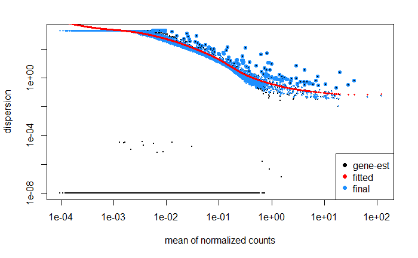

```r
# Plot dispersion estimates
plotDispEsts(dds)
```

Now that we have performed the differential expression analysis, we can explore our results for a particular comparison. To denote our comparison of interest, we need to specify the contrast and perform shrinkage of the log2 fold changes.

Let’s compare the stimulated group relative to the control:

```r
resultsNames(dds)
```

```
[1] "Intercept"             "group_id_stim_vs_ctrl"
```

```r
res <- lfcShrink(dds,
                 coef =  2,
                 res=res)
```

```
using 'apeglm' for LFC shrinkage. If used in published research, please cite:
    Zhu, A., Ibrahim, J.G., Love, M.I. (2018) Heavy-tailed prior distributions for
    sequence count data: removing the noise and preserving large differences.
    Bioinformatics. https://doi.org/10.1093/bioinformatics/bty895
```

```r
res_tbl <- res %>%
        data.frame() %>%
        rownames_to_column(var="gene") %>%
        as_tibble()

# Check results output
res_tbl
```

| gene | baseMean | log2FoldChange | lfcSE | pvalue | padj |
| --- | --- | --- | --- | --- | --- |
| AL627309.1 | 1.057201e-03 | 1.315853e-02 | 0.26724023 | 9.880648e-01 | 9.999060e-01 |
| AL669831.5 | 3.527748e-03 | -1.220032e-02 | 0.26554616 | 9.756467e-01 | 9.999060e-01 |
| LINC00115 | 3.529350e-03 | 3.117856e-03 | 0.26619427 | 9.862568e-01 | 9.999060e-01 |
| FAM41C | 1.008228e-02 | -9.297991e-02 | 0.28922236 | 9.331490e-01 | 9.999060e-01 |
| NOC2L | 1.338907e-01 | -2.064206e-01 | 0.21054831 | 4.460000e-01 | 9.999060e-01 |
| KLHL17 | 1.627454e-03 | -9.569156e-03 | 0.26663091 | 9.863017e-01 | 9.999060e-01 |
| PLEKHN1 | 1.124161e-03 | 1.550290e-02 | 0.26742450 | 9.897157e-01 | 9.999060e-01 |
| HES4 | 5.914810e-02 | 1.272789e+00 | 0.63607442 | 7.193402e-01 | 9.999060e-01 |
| ISG15 | 7.619720e+00 | 5.428688e+00 | 0.08324897 | 0.000000e+00 | 0.000000e+00 |
| AGRN | 1.615326e-03 | 1.345801e-03 | 0.26625885 | 9.880210e-01 | 9.999060e-01 |

[output cut: 990 more lines]

Table of results for significant genes

Next, we can filter our table for only the significant genes using a p-adjusted threshold of 0.05

```r
# Set thresholds
padj_cutoff <- 0.05

# Subset the significant results
sig_res <- dplyr::filter(res_tbl, padj < padj_cutoff) %>%
        dplyr::arrange(padj)

# Check significant genes output
sig_res
```

| gene | baseMean | log2FoldChange | lfcSE | pvalue | padj |
| --- | --- | --- | --- | --- | --- |
| ISG15 | 7.6197203 | 5.42868758 | 0.08324897 | 0.000000e+00 | 0.000000e+00 |
| IFI6 | 2.5012186 | 5.45588570 | 0.13462251 | 0.000000e+00 | 0.000000e+00 |
| PLSCR1 | 1.1885644 | 4.09886414 | 0.13054648 | 0.000000e+00 | 0.000000e+00 |
| TNFSF10 | 1.2193392 | 5.86023917 | 0.22144873 | 0.000000e+00 | 0.000000e+00 |
| CXCL10 | 4.2677707 | 7.92768571 | 0.26632793 | 0.000000e+00 | 0.000000e+00 |
| LY6E | 1.7460213 | 4.00511927 | 0.10496030 | 0.000000e+00 | 0.000000e+00 |
| IRF7 | 1.4055955 | 3.52779838 | 0.10390106 | 0.000000e+00 | 0.000000e+00 |
| IFIT2 | 1.3230134 | 6.03172324 | 0.22697256 | 0.000000e+00 | 0.000000e+00 |
| IFIT3 | 2.6512335 | 6.64647563 | 0.19332051 | 0.000000e+00 | 0.000000e+00 |
| IFIT1 | 1.7718308 | 6.44488826 | 0.22187339 | 0.000000e+00 | 0.000000e+00 |

[output cut: 434 more lines]

# Scatter plot of top 20 genes

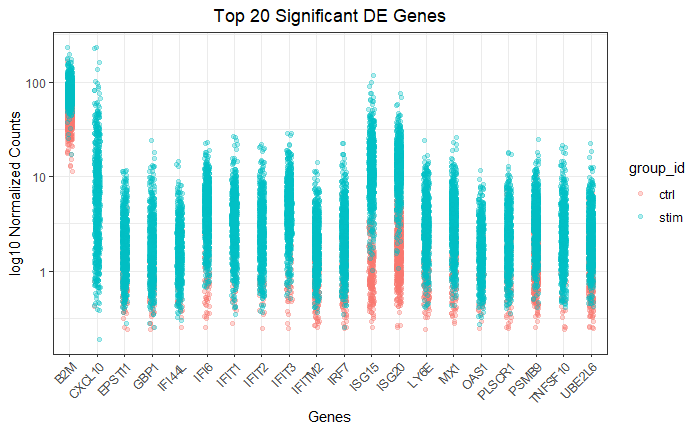

```r
## plot using ggplot2
ggplot(gathered_top20_sig) +
        geom_point(aes(x = gene,
                       y = normalized_counts,
                       color = group_id),
                   position=position_jitter(w=0.1,h=0), alpha=0.3) +
        scale_y_log10() +
        xlab("Genes") +
        ylab("log10 Normalized Counts") +
        ggtitle("Top 20 Significant DE Genes") +
        theme_bw() +
        theme(axis.text.x = element_text(angle = 45, hjust = 1)) +
        theme(plot.title = element_text(hjust = 0.5))
```

# Volcano plot

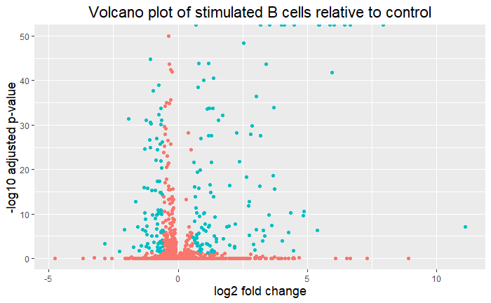

```r
## Obtain logical vector where TRUE values denote padj values < 0.05 and fold change > 1.5 in either direction
res_table_thres <- res_tbl %>%
                  mutate(threshold = padj < 0.05 & abs(log2FoldChange) >= 0.58)

## Volcano plot
ggplot(res_table_thres) +
    geom_point(aes(x = log2FoldChange, y = -log10(padj), colour = threshold)) +
    ggtitle("Volcano plot of stimulated B cells relative to control") +
    xlab("log2 fold change") +
    ylab("-log10 adjusted p-value") +
    scale_y_continuous(limits = c(0,50)) +
    theme(legend.position = "none",
          plot.title = element_text(size = rel(1.5), hjust = 0.5),
          axis.title = element_text(size = rel(1.25)))
```

```r
library(org.Hs.eg.db)
```